# Pinpointing Causality Between Lifestyle Behaviors and Health: Benefits of Volunteering in Old Age

Author

Danielle Fischer and Sophie McDowall

Published

August 12, 2025

## Abstract

To better understand how certain activities can contribute to positive life outcomes in older adults, the University of Michigan has directed a longitudinal study surveying around 20,000 Americans, building a database for analyzing questions related to challenges and opportunities in aging. One area of interest is the potential benefits of social volunteering for older adults. Our paper seeks to answer the question of whether volunteering can cause positive changes in physical, mental, and emotional health. We assess existing literature, much of which stops at identifying correlational relationships between postive health outcomes and volunteering. Our research seeks to continue on toward identification of causal relationships through the use of propensity scoring on pre-existing covariates to balance our analysis and determine more directly the impacts of volunteering on different health outcomes.

## Introduction

As people age and reach retirement, they often consider how they can best maintain their physical health, mental health, and overall life satisfaction. Understanding and paying attention to the activities that can decrease risks for serious illnesses, especially those that more significantly impact those in later life, is important to maintaining quality of life in a society. The University of Michigan Health and Retirement Study (HRS) is a longitudinal study surveying around 20,000 Americans to build a database for analyzing questions related to challenges and opportunities of aging. Many studies use this database to analyze the effects of different lifestyle practices on various measures of health (Lum and Lightfoot (2005), E. S. Kim et al. (2020)). Causal relationships can be difficult to identify when related to lifestyle practices and health benefits because of the difficulty of isolating variables and controlling for outcomes. Our research seeks to address this challenge by assessing existing work on the effects of volunteering on the health of aging populations including analysis on mental and physical health. We plan to improve on existing research by identifying gaps in causational analysis and potential methods for further assessment of causality between lifestyle practices and health outcomes, focusing on errors related to selection bias, lack of baseline controls, and limited models. Building on prior findings that link volunteering to reduced depression, slower decline in self-rated health, and lower mortality, we aim to evaluate whether these associations hold once important confounders are accounted for. Observational studies in this space are often limited by self-selection into volunteering, which creates systematic differences between groups that can bias results. By identifying and adjusting for these differences, we aim to clarify whether volunteering itself produces meaningful health benefits or if the associations reported in past research primarily reflect pre-existing advantages among volunteers. Our project will use the extensive data in HRS to examine these relationships, focusing on outcomes such as mental health, physical functioning, and reported well being. We hope that by using an extensive set of covariates, we will be able to account for different factors and hidden influences that influence both volunteering and health outcomes.

## Literature Review/Background

We use the Health and Retirement Study dataset for our analysis. The HRS (Health and Retirement Study) is sponsored by the National Institute on Aging (grant number NIA U01AG009740) and is conducted by the University of Michigan(Michigan (2022)). This dataset provides longitudinal data on around 20,000 Americans including data on health, mobility, demographic, values, and more. Numerous analytical studies use this data to identify correlations between different life practices and health outcomes, including many specifically looking at the impact of social volunteering on health for older adults. Many of these reports highlight correlations between social volunteering and physical and mental health.

Lum and Lightfoot (2005) used the dataset to examine whether volunteering 100+ hours per year is associated with better health outcomes for people over the age of 70. They found that volunteering is associated with a slower decline in self-reported health and functioning, lower rates of depression, and lower mortality rates. Their research mainly uses regression analysis to show a strong association, but lacks methods to account for potential self-selection.

E. S. Kim et al. (2020) used HRS data for adults over 50 to identify whether changes in volunteering is linked to changes in various health and wellbeing outcomes, finding links between volunteering more than 100 hours per year is linked with lower mortality. Their research controlled for many covariates, and used covariate adjustment in their regression.

Lorenti, De Rose, and Racioppi (2025) looks at connections between depression and volunteering, finding that volunteering reduces the probability of depression among early retirees, especially for women. The research considers co-variates including employment, partnership status, income, and health comorbidities.

S. Kim, Halvorsen, and Han (2023) assess direct association between volunteering and heart conditions, studying seven cardiovascular disease biomarkers. They found associations between volunteering 200+ hours a year and a lower risk for clinically high diastolic blood pressure, as well as an association between increased volunteering and lower likelihoods of blood pressure. They sought a more specific approach than studies that identify broad impacts. They used propensity score weighting (IPTW or inverse probablity of treatment weighting) to adjust their selection into volunteering based on factors related to age, gender, race, Hispanic ethnicity, education, employment status, health, depressive symptoms, marital status, informal volunteering, wealth, and income. This is a good example of an exhaustive selection of attributes to account for in potential pre-selection.

Many of these studies do a good job of addressing various potential co-variates through the use of propensity scores and other methods. Some do not use the most effective approaches to control such variables and therefore cannot identify strong causal relationships beyond correlations.

## Missing Pieces: Causality

While many of these studies find that older adults who volunteer report better mental health and overall wellbeing in various health categories, the research is primarily correlational. Some studies do identify and account for potential co-variates, but there is still a space for greater research that moves from the correlational observations of consistent trends and identifies causational patterns between volunteering and various health benefits in old age.

While volunteering itself may cause better health for various reasons, it is necessary to consider many factors that may contribute to both health outcomes and likelihood to volunteer. For example, older adults who volunteer are likely already healthy enough to be mobile or independent, allowing them to volunteer. It is possible that older adults who are suffering from chronic or severe illness or health burdens are not as physically capable of volunteering, introducing a selection bias. Another factor to consider is socio-economic status. Wealthier adults may have more time to dedicate to volunteering, while also having the funds necessary to ease other burdens that can contribute to health problems. Social connection also could impact these results. Much of the literature cites the social benefit of volunteering as a potential contributing factor to improved health outcomes.

Although a handful of studies have begun using propensity score matching to address selection bias, these approaches often remain limited. Many rely on a limited set of covariates or focus only on a narrow set of outcomes such as mortality or physical health biomarkers. We hope to build on these efforts by examining the results across several health outcomes and subgroups, allowing us to better understand the possible health benefits of volunteering in old age.

## Closing The Gap

In order to address this gap, our research aims to use propensity score weighting to achieve stronger results that move beyond correlation toward causation. By leveraging this approach on longitudinal HRS data, we aim to better account for baseline differences between volunteers and non-volunteers and reduce bias caused by self-selection. We will also explore subgroup-specific effects to understand how benefits may vary across populations.

Potential areas to address:

- Similar underlying health conditions: do people with similar chronic or burdensome health conditions demonstrate differences in these or other conditions when volunteering compared to others with the same conditions? ex mobility
- Socio-economic status: does the outcome hold when balanced across socio-economic groups?
- Intensity of volunteering: are effects stronger for individuals who volunteer more frequently compared to occassional volunteers, after controlling for confounders?
- Differences by age group: are causal effects different for different age ranges of older adults, after adjusting for covariates like functional limitations?

## Methodology

### Data Organization and Cleaning

The HRS data contains tens of thousands of data points on a wide range of areas related to values, personal history, family status, health, mobility, and more in alphabetically labeled groups. The tables below lists covariates that we account for, the corresponding dataset from the survey, and some variables that fit into the category.

We used the HRS datasets for the years 2020 and 2022. From these data sets, we pulled variables for our targets, predictors, and covariates for propensity scoring. We chose three variables to represent target categories related to physical health, mental health, and overall life satisfaction, two variables representing predictors of volunteering, and 12 variables on a variety of themes to include in the propensity scores. Each of the original datapoints we pulled to use as covariates are listed in the table below. Unfortunately, many of these covariates had high proportions of NA values, and to preserve our ability to model the data we dropped any covariates that had greater than 50% NA values. This left us with four covariates: heart condition, depression, alzheimers, and employment status. While this heavily reduced some of the areas we wanted to focus on like mobility, ability to drive, race, and weak immune system, we still are able to use features representing measures of physical health, mental health, and socialization. Our final variables used are bolded in the table below. We cleaned each of these datasets to normalize for discrepancies in NA values, removed and unified labels, and combined our different data categories to perform our analysis. We used data on the covariates from 2020 alongside data for the predictors and outcomes in 2022 to identify the impact of existing conditions on later outcomes related to volunteer work.

List of Variables Drawn from HRS Dataset (*Final Selected Variables*)

[output not shown]

### Modeling Approach

Once we had cleaned, unified, and combined our data, we used propensity scores based on the 2020 covariates to account for potential self-selection into or out of volunteering. To understand the benefits of propensity weights, we used multiple approaches.

We first used linear regression to predict our three target variables based solely on the different volunteering categories. Then, we calculated propensity weights based on our chosen covariates and ran the model again.

## Results

We had two main findings:

1. Including propensity scores helped to produce more accurate results.
2. The propensity scores were consistent with existing literature that volunteering has positive outcomes, though with slightly less influence than strictly correlational models.

First, when running the linear regression with and without the propensity scores, we found that the model including propensity scores performed better across all metrics.

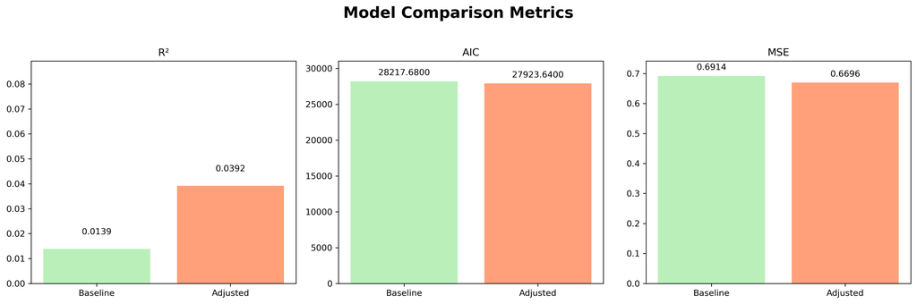

Baseline vs. Adjusted Model Metric Comparison

Here, the baseline model represents the initial model run only on the volunteering categories and the adjusted model represents the model including propensity scores. As shown in Figure 1, the R² score is higher for the adjusted model, meaning that it explains more of the outcome variance. The adjusted model also has a lower AIC which means it was able to fit the data better. Finally, the MSE for the adjusted model is slightly lower than the baseline, indicating greater accuracy in predicting outcomes.

### Propensity Score Weighting

Then, we studied whether volunteers in the past 12 months (2022) is associated with (i) life satisfaction (1-5, higher = better), (ii) self-rated physical health (1-5, higher = better), and (iii) depression in the past 12 months (binary). Following our pre-analysis plan, treatments and outcomes are from 2022, and covariates are from 2020 (pre-treatment).

The final sample includes N=11,415 respondents (non-volunteers n = 8,244, 72.2%; volunteers n = 3,171, 27.8%)

#### Exploratory (naive) comparisons

We begin by describing outcomes by volunteering status in 2022, without any adjustment for baseline differences.

| Group | n | % of sample |
| --- | --- | --- |
| Non-volunteers | 8,244 | 72.2% |
| Volunteers | 3,171 | 27.8% |

The following table shows the unadjusted outcomes.

| Outcome (higher = better where applicable) | Non-volunteers | Volunteers | Raw difference |
| --- | --- | --- | --- |
| Life satisfaction (1–5) | 3.80 | **4.02** | **+0.22** |
| Self-rated physical health (1–5) | 2.98 | **3.43** | **+0.45** |
| Depressed in past year (binary) | 19.6% | **13.2%** | **−6.4 pp** |

These are unadjusted differences and likely reflect both causal effects and selection into volunteering. We hypothesized that volunteers may be more healthy by nature, as we assumed healthier people may be more inclined to volunteer.

#### Propensity Score Weighting and Covariate balance

| Outcome | Naïve estimate | IPTW estimate | Interpretation |
| --- | --- | --- | --- |
| Life satisfaction (1–5; OLS) | +0.218 | **+0.181** | Volunteers ≈ **0.18 points** higher. |
| Health rating (1–5; OLS) | +0.452 | **+0.360** | Volunteers ≈ **0.36 points** higher. |
| Depression (logit; OR) | 0.626 (0.557–0.703) | **0.722 (0.654–0.798)** | ≈ **28% lower odds** after weighting. |

#### Interpretation of Results

Across three outcomes, volunteering is associated with better well-being. The magnitude of the association decreases after balancing 2020 covariates, which is consistent with the idea that volunteers are positively selected, but it still remains meaningful.

- A ~0.18 to 0.36 increase on 1-5 scales for life satisfaction and health
- ~28% lower odds of depression

These results are consistent with a beneficial effect of volunteering. However, there were very many limitations to our study. It is possible that other covariates that we were unable to account for due to lack of presence in the data or a large amount of missingness would have changed the outcomes here, but from what we were able to capture it does appear that volunteering has beneficial effects on life.

## Limitations and Future Considerations

As mentioned above, one of the most limiting factors of our research was the high percentage of NA values in many of the covariates that we originally wanted to include in our propensity scores. Future research into the topic could do a more exhaustive assessment of the hundreds of questions in the dataset to identify as many possible covariates with a sufficient amount of data to model. Although we were unable to perform this level of analysis due to time constraints, this could potentially inform more effective propensity metrics by incorporating additional covariates for the target areas for potential self-selection to volunteer work such as wealth, financial stability, social isolation or connection, physical mobility, and additional physical and mental health factors.

## Conclusion

Through this research project, we learned the value of applying propensity scoring methods to fill gaps in existing research. By understanding the potential contributing factors to an outcome and controlling for these factors, researchers can better understand direct outcomes from various activities and relationships between different lifestyle decisions. This type of research can be applied across social science in many different areas of focus, and the goal of moving toward understanding causal relationships beyond just correlation can potentially help people make smarter life choices that they can trust are connected to better physical health, mental health, and life satisfaction.

## References

Kim, Erica S, Ashley V Whillans, Matthew T Lee, Ying Chen, and Tyler J VanderWeele. 2020. “Volunteering and Subsequent Health and Well-Being in Older Adults: An Outcome-Wide Longitudinal Approach.” *American Journal of Preventive Medicine* 59(2) (August): 176–86. https://doi.org/10.1016/j.amepre.2020.03.004.

Kim, Seoyoun, Cal Halvorsen, and Sae Hwang Han. 2023. “Volunteering and Changes in Cardiovascular Biomarkers: Longitudinal Evidence from the Health and Retirement Study.” *Innovation in Aging* 7(5). https://doi.org/10.1016/j.socscimed.2025.117790.

Lorenti, Angelo, Alessandra De Rose, and Filomena Racioppi. 2025. “Volunteering During Early Retirement Reduces Depression.” *Social Science & Medicine* 367. https://doi.org/10.1016/j.socscimed.2025.117790.

Lum, Terry Y, and Elizabeth Lightfoot. 2005. “Effects of Volunteering on the Physical and Mental Health of Older People.” *Research on Aging* 27 (January): 31–55. https://doi.org/10.1177/0164027504271349.

Michigan, University of. 2022. “Health and Retirement Study Public Use Dataset.” https://hrsdata.isr.umich.edu/data-products/.